# Econometrics 2 capstone proposal code

Josh Copeland, Jocelyn Koswara and Ryan Luo

2024-08-11

# Importing and cleaning data

Tables used for this proposal:

- Psychology (S10AI)
- Housing: water (S12AI)
- Housing: sewage facilities (S12AII)
- Household background information (S1D)

Analysis in this markdown document is separated by each data table imported.

### Importing the Pyschology table

```r
################################################################################
################################ PSYCHOLOGY TABLE ##############################
################################################################################

s10ai <- read_csv("data/S10AI.csv") %>%
  select(hhno, hhmid, depression, sex = s1d_1, age = s1d_4i) %>%

  #Creating a new column as our depression_dummy. Kessler scores between 10-19 have a score of one in the data (== "likely to be well"). Anyone with scored higher than this has a score > 1, which classifies them as likely to have at least a mild disorder.
  mutate(depression_dummy = case_when(

    depression > 1 ~ 1, # Depressed
    TRUE ~ 0 # Not depressed

  )) %>%

  # Turning sex into a dummy variable (1 == female)

  mutate(sex = case_when(

    sex == 1 ~ 0,
    sex == 2 ~ 1

  ))


######################## EXTRACTING JUST THE RELEVANT VARIABLES ################

s10ai <- s10ai %>%
  select(hhno, hhmid, depression_dummy, sex_dummy = sex, age)
```

### Importing the housing tables

In the following order:

- Water
- Sewerage

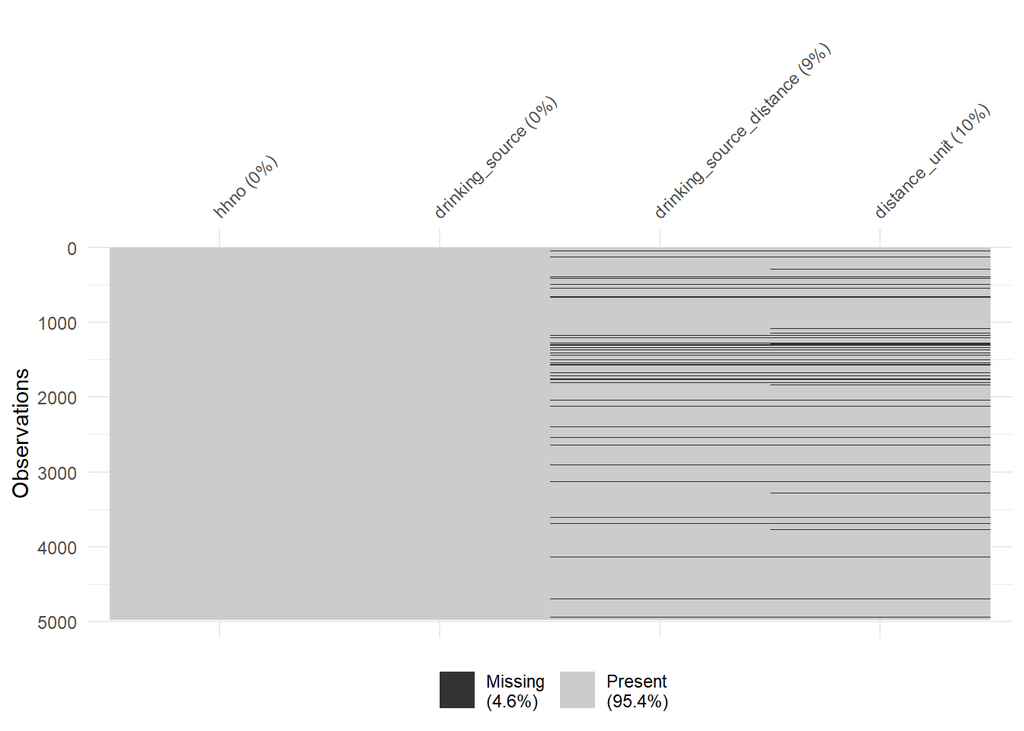

```r
################################################################################
############################### HOUSING TABLES #################################
################################################################################

############################### WATER TABLE ####################################

s12ai <- read_csv("data/S12AI.csv") %>%
  select(hhno,drinking_source = s12a_9i, drinking_source_distance = s12a_10ai, distance_unit = s12a_10aii) %>%

  #Editing the drinking_source_distance cells to make them all the same scale: metres.

  mutate(drinking_source_distance = case_when(

    distance_unit == 0 ~ 0,  # In house
    distance_unit == 1 ~ 0,  # In yard (assuming 0 meters)
    distance_unit == 2 ~ as.numeric(drinking_source_distance),  # Already in meters
    distance_unit == 3 ~ as.numeric(drinking_source_distance) * 1000,  # Kilometers to meters
    distance_unit == 4 ~ as.numeric(drinking_source_distance) * 1609.344,  # Miles to meters
    TRUE ~ drinking_source_distance

  ))
vis_miss(s12ai)
```

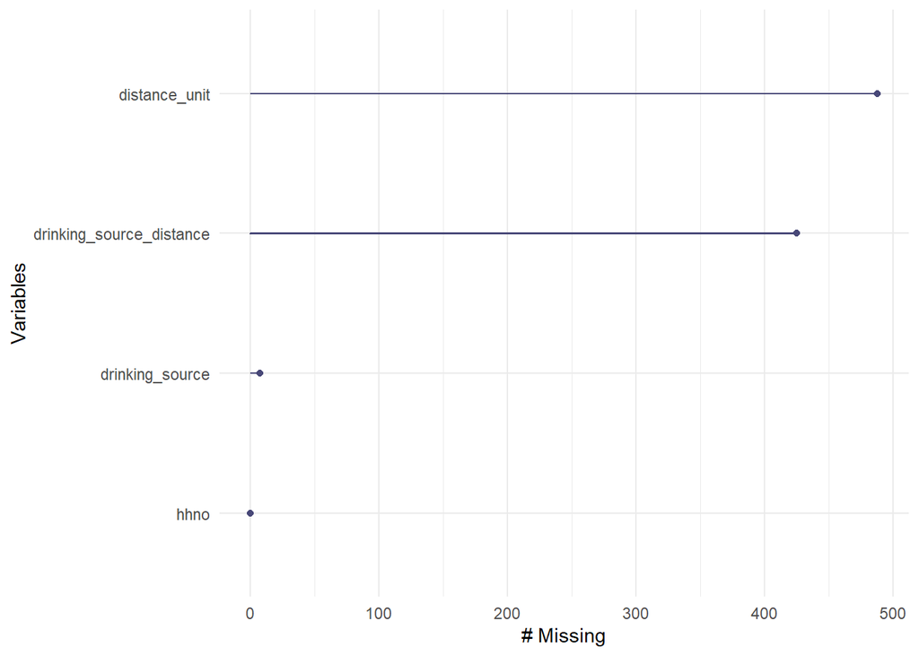

```r
gg_miss_var(s12ai)
```

The chart above shows us that there is a lot of missing values for distance_unit. This likely have something to do with the drinking source of each household. I need to collect all the NA data together in order to diagnose the problem.

The chart below shows us that:

- Most of the problem is in 1 and 2, which corresponds to plumbing in the house. We can change their distances to zero.
- 8 is also a clear problem, which is bottled water. Therefore leave this as NA.
- 9 and 10 are protected wells and boreholes. Without more information about how far away they are (unavailable) we need to leave these as NAs.

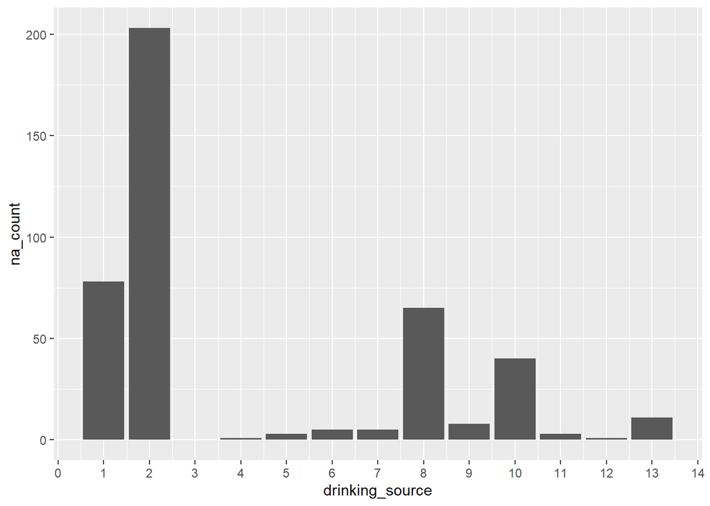

```r
# Extracting and charting NA data

na_data <- s12ai %>%
  filter(is.na(drinking_source_distance)) %>%
  group_by(drinking_source) %>%
  summarise(na_count = n())

ggplot(na_data, aes(x = drinking_source, y = na_count)) +
  geom_bar(stat = "identity") +
  scale_x_continuous(breaks = scales::pretty_breaks(n = 14))
```

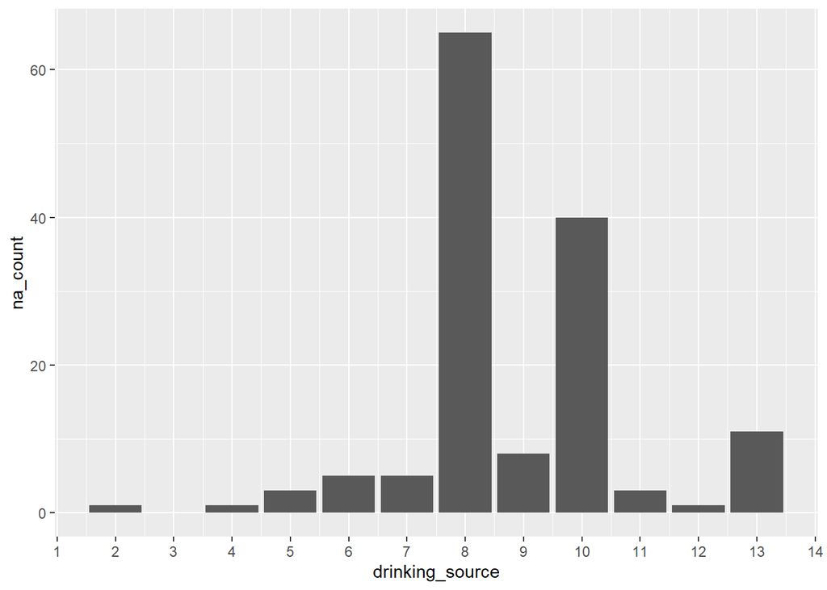

```r
# Now I have diagnosed the problem, I need to make the necessary changes to the dataframe such that dirnking_sources with values 1 and 2 have a distance of zero. All other NAs remain given data limitations.

s12ai <- s12ai %>%
  mutate(drinking_source_distance = case_when(

    is.na(distance_unit) & drinking_source %in% c(1, 2) ~ 0,
    TRUE ~ drinking_source_distance
  ))



# Repeating the NA value analysis/chart below, the scale are now sufficiently small to continue/we don't have any other information that could help reduce the incidence of NAs.

na_data <- s12ai %>%
  filter(is.na(drinking_source_distance)) %>%
  group_by(drinking_source) %>%
  summarise(na_count = n())

ggplot(na_data, aes(x = drinking_source, y = na_count)) +
  geom_bar(stat = "identity") +
  scale_x_continuous(breaks = scales::pretty_breaks(n = 14))
```

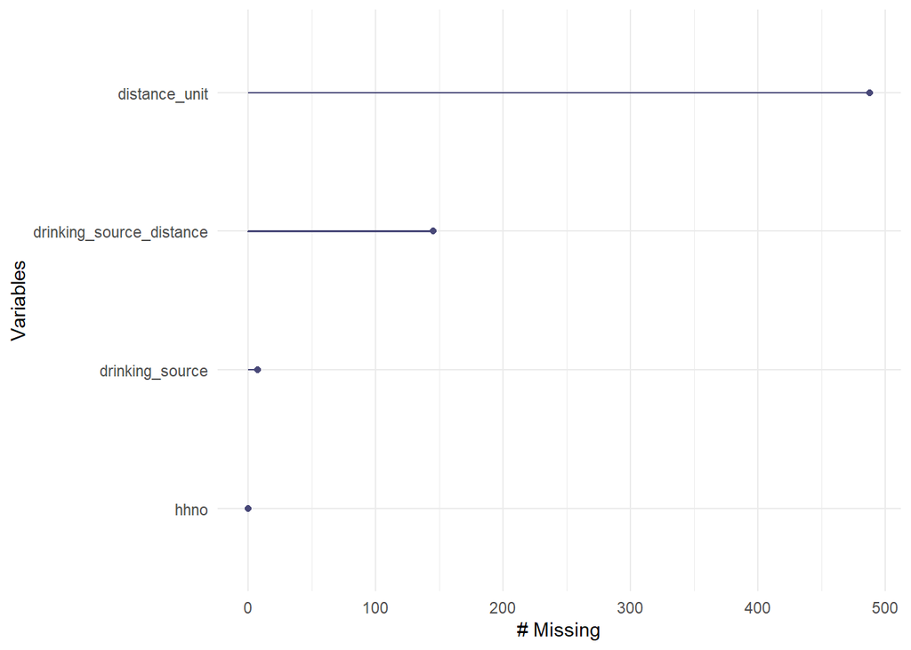

```r
gg_miss_var(s12ai)
```

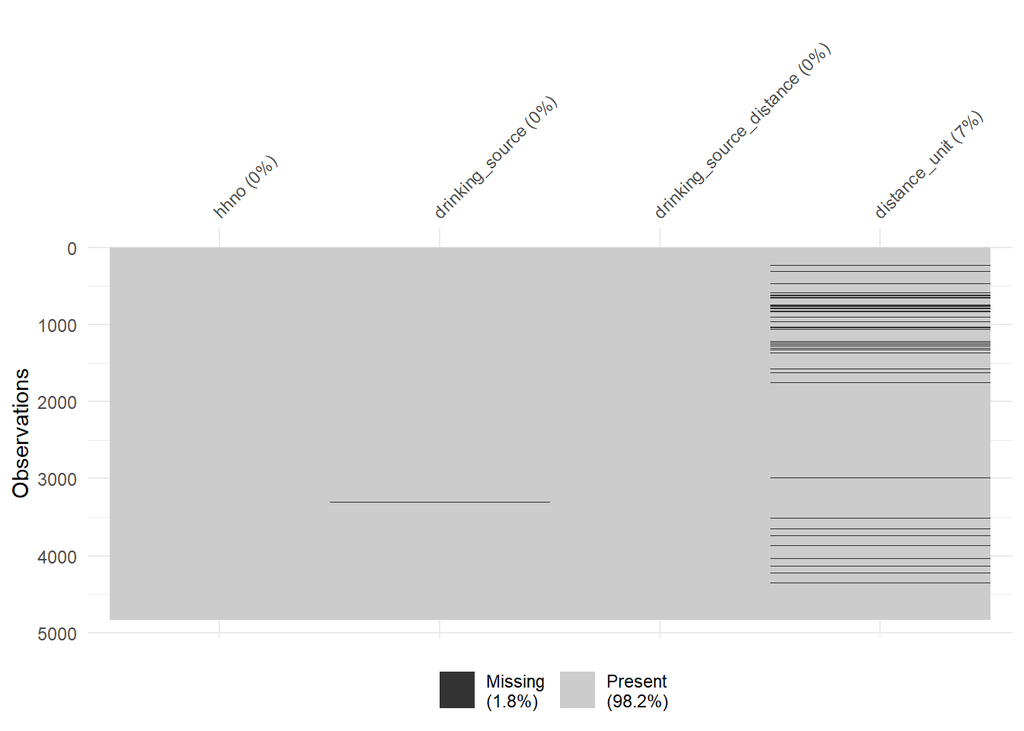

```r
# Because we can't deal with the remaining NAs, we exclude them from our analysis. However, we only exclude where NAs appear in the drinking_source_distance variable.

s12ai <- s12ai %>%
  filter(!is.na(drinking_source_distance))

vis_miss(s12ai)
```

```r
######################## EXTRACTING JUST THE RELEVANT VARIABLES ################

s12ai <- s12ai %>%
  select(hhno, drinking_source_distance)


############################### SEWERAGE TABLE #################################

s12aii <- read_csv("data/S12AII.csv") %>%
  select(hhno, sewerage_dummy = s12b_23)
```

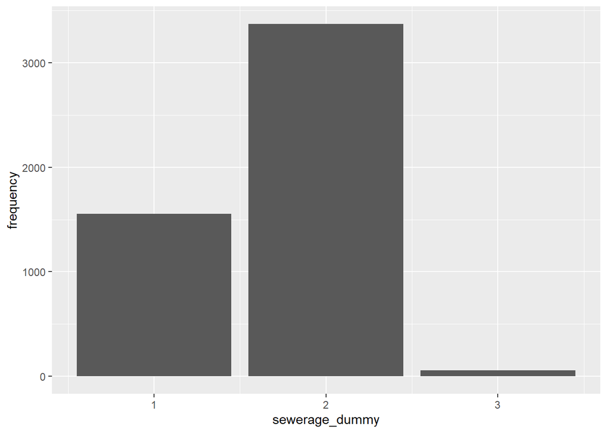

```r
  # Is there any open sewer,drain in/around the house? Note: 1 == Yes, 2 == No, 3 == Drains are covered

frequency_test <- s12aii %>%
    group_by(sewerage_dummy) %>%
  summarise(frequency = n())

ggplot(frequency_test, aes(x = sewerage_dummy, y = frequency)) + geom_bar(stat = "identity")
```

```r
# Given how infrequently option 3 occurs, we are going to exclude it to ensure our variable actually as a dummy. We then need to make sure values are between 0 and 1.

s12aii <- s12aii %>%
  filter(sewerage_dummy != 3) %>%

  # Turning variable into actual dummy variable (exposure == 1)
  mutate(sewerage_exposure_dummy = case_when(

    sewerage_dummy == 2 ~ 0,
    sewerage_dummy == 1 ~ 1

  ))


######################## EXTRACTING JUST THE RELEVANT VARIABLES ################

s12aii <- s12aii %>%
  select(hhno, sewerage_exposure_dummy)
```